# Hill House Ticket Sales Analysis

# Executive Summary

Interventions begun in the holiday season of FY18 resulted in more than $40,000 of additional sales over the previous year – three quarters of which were web sales. The additional sales were concentrated in Nov and Dec. The monthly BOX sales rate has remained at roughly half its FY17 rate for months other than Nov and Dec. Sales for FY19 are likely to be comparable to those of FY18; if current trends continue, we can expect year-end totals near $250,000.

## Overall Admissions

This section gives an overview of Hill House ticket sale trends. The data is from Tessitura, exclusively, and we’ve excluded sales from Programs, Other Attendance, and Adult Groups. Since presales for Hill House didn’t start until 7/4/16, we’ve also excluded data from before that date. All dates are *performance dates*, the date of the event for which the ticket was sold, rather than *order dates*, the date at which the ticket order was placed.

The following plot compares the current fiscal year’s General Admission ticket sale progress (through 12/26/18) with that of the prior two years:

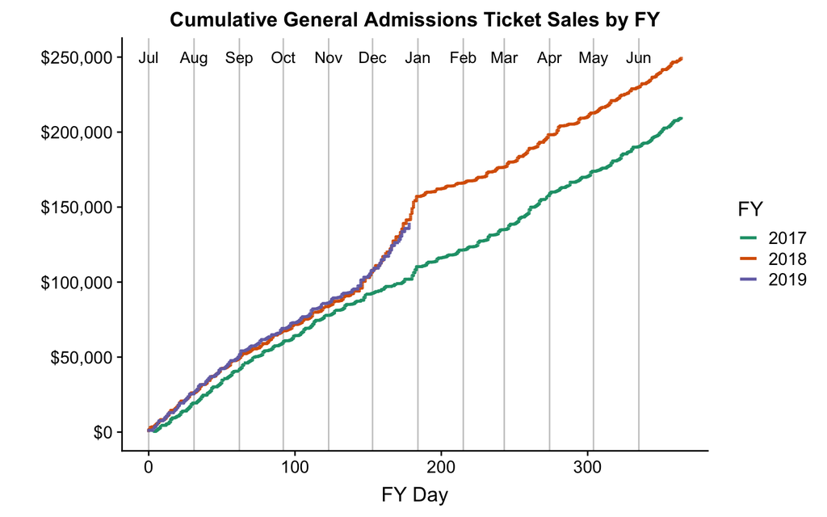

It’s evident that sales for FY19 are tracking those of FY18 as of late December. The following table compares total sales in the period extending from the beginning of the fiscal year through fiscal week 24 for FY17-19.

| FY | Total sales through fiscal week 24 |
| --- | --- |
| 2017 | $100,430 |
| 2018 | $139,088 |
| 2019 | $133,676 |

We can see that, as of FW24, this year’s cumulative sales differ from FY19’s by less than $5500, and are $33,246 higher than those of FY17’s.

The following plot of monthly sales totals further illustrates the similarity of FY18’s and FY19’s sales trajectories:

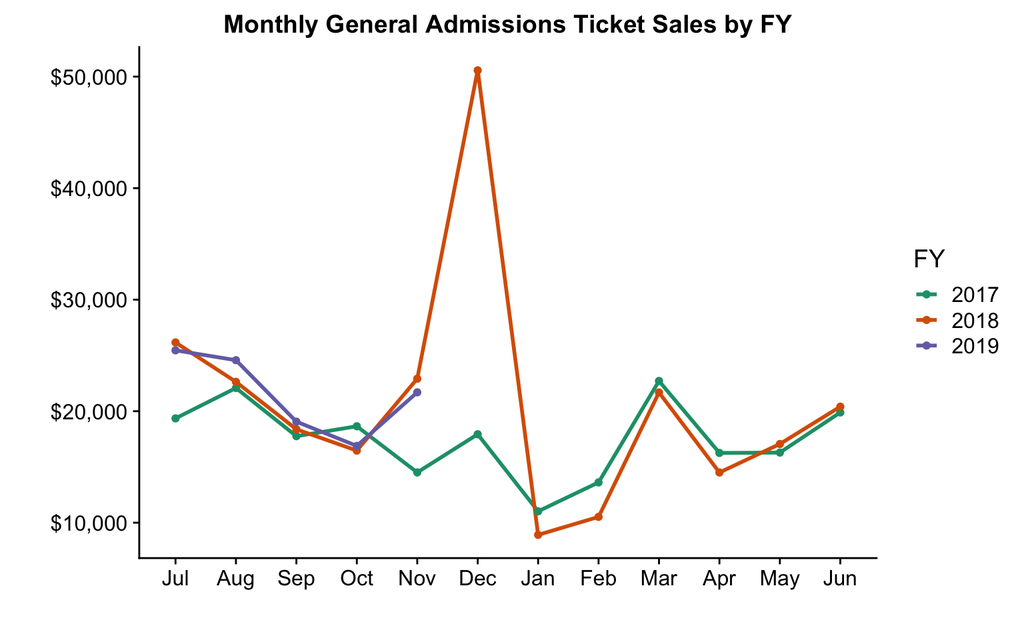

It’s also evident that the large difference in FY18 year-end totals between was due entirely to much higher Nov and Dec sales; the nearly three-fold increase is suspected to be the result of the following changes made in the foregoing period:

- ticket prices for Christmas tours were raised and, for the first time, members were charged for these tickets;
- Hill House made a much larger number of tickets available for online purchase;
- a new Hill House website was launched

It’s likely that these interventions yielded over $40,000 in additional revenue for FY18 and, since it’s clear that month-totals for this Dec will be comparable to those of FY18, it’s possible that by the end of this fiscal year, Hill House will have accumulated a two year total of roughly $80,000 in extra revenue attributable to those changes.

Also relevant is the implementation of the Christmas Saturdays program in FY18. This successful program resulted in no Christmas tours on Saturdays during the holiday season. The above interventions still provided enough additional revenue for General Admission sales that the lack of a Saturday Christmas tour did not affect the month total.

Note that the FY18 sales spike was followed by two months of lower-than-FY17 sales totals, possibly indicating that the Dec spike absorbed sales that would otherwise have occured in Jan and Feb.

## Admissions by Mode of Sale (MOS)

In this section, we provide an overview that is analogous to the previous one’s, but we distinguish between various Modes of Sale (MOS). We first compare presales to walkups and second compare Web, BOX, and HIL sales.

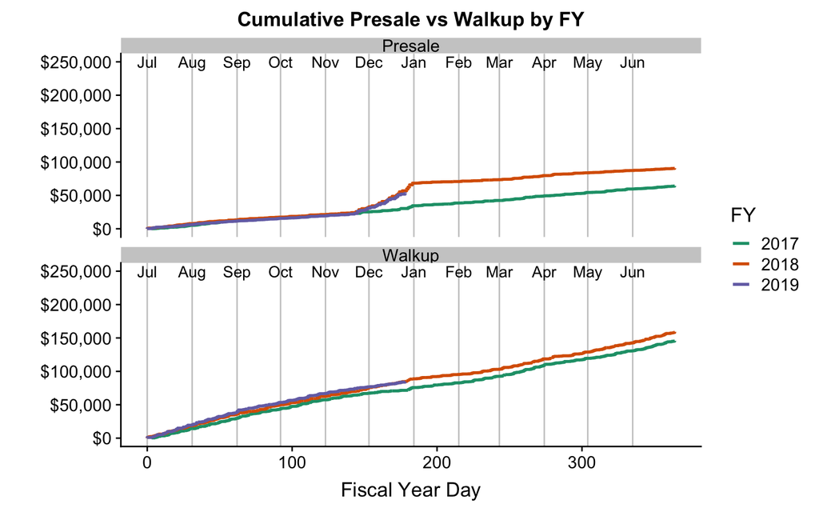

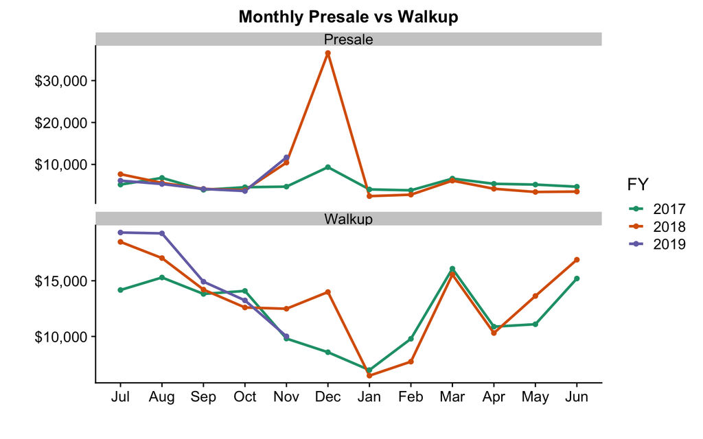

| FY | Presales through fiscal week 24 | Walkups through fiscal week 24 |
| --- | --- | --- |
| 2017 | $29,158.00 | $71,272.00 |
| 2018 | $55,352.00 | $83,736.00 |
| 2019 | $50,740.40 | $82,935.60 |

It can now be observed that, athough Nov and Dec sales were higher for both MOS, it was presales that dominated the FY18 increase – as expected given the nature of the interventions.

In fact, in what follows, it’s revealed that web sales were the largest component of the sales increase:

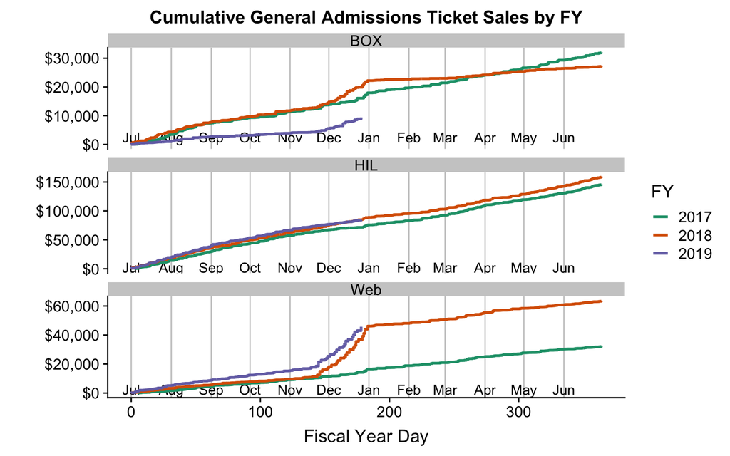

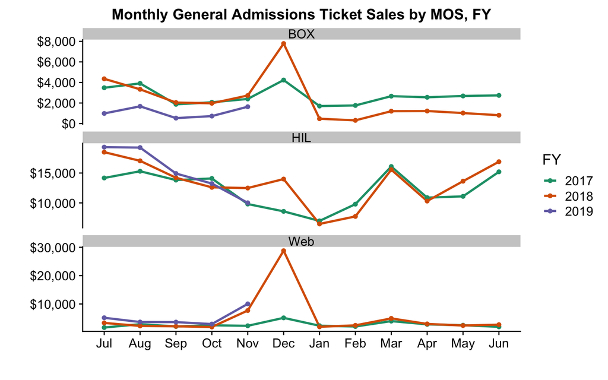

| FY | BOX sales through fiscal week 24 | HIL sales through fiscal week 24 | Web sales through fiscal week 24 |
| --- | --- | --- | --- |
| 2017 | $15,378.00 | $71,272.00 | $13,780.00 |
| 2018 | $19,810.00 | $83,736.00 | $35,542.00 |
| 2019 | $8,596.80 | $82,935.60 | $42,143.60 |

Over three quarters of FY18’s $40,000 dollar increase came from web sales. BOX tickets have been selling at roughly half their pre-intervention rate. Interestingly, web sales did not stabilize at a higher monthly rate after intervention; it’s unclear where, on a month-to-month basis, these sales went, since neither of the other monthly rates increased. We can only speculate that BOX sales which would otherwise have been realized steadily over the course of the year were sold all at once in Nov and Dec, possibly in other MOS.